# Week 4 Project Write Up

```r
## This function will find the null values in each column in training
na_count_training <-sapply(training, function(y) sum(length(which(is.na(y)))))

## Show how many nulls are in each column using the new function
na_count_training <- data.frame(na_count_training)
na_count_training
```

```
##                          na_count_training
## X                                        0
## user_name                                0
## raw_timestamp_part_1                     0
## raw_timestamp_part_2                     0
## cvtd_timestamp                           0
## new_window                               0
## num_window                               0
## roll_belt                                0
## pitch_belt                               0
## yaw_belt                                 0
## total_accel_belt                         0
## kurtosis_roll_belt                   19226
## kurtosis_picth_belt                  19248
## kurtosis_yaw_belt                    19622
## skewness_roll_belt                   19225
## skewness_roll_belt.1                 19248
## skewness_yaw_belt                    19622
## max_roll_belt                        19216
## max_picth_belt                       19216
## max_yaw_belt                         19226
## min_roll_belt                        19216
## min_pitch_belt                       19216
## min_yaw_belt                         19226
## amplitude_roll_belt                  19216
## amplitude_pitch_belt                 19216
## amplitude_yaw_belt                   19226
## var_total_accel_belt                 19216
## avg_roll_belt                        19216
## stddev_roll_belt                     19216
## var_roll_belt                        19216
## avg_pitch_belt                       19216
## stddev_pitch_belt                    19216
## var_pitch_belt                       19216
## avg_yaw_belt                         19216
## stddev_yaw_belt                      19216
## var_yaw_belt                         19216
## gyros_belt_x                             0
## gyros_belt_y                             0
## gyros_belt_z                             0
```

[output cut: 106 more lines]

```
## stddev_pitch_forearm                 19216
## var_pitch_forearm                    19216
## avg_yaw_forearm                      19216
## stddev_yaw_forearm                   19216
## var_yaw_forearm                      19216
## gyros_forearm_x                          0
## gyros_forearm_y                          0
## gyros_forearm_z                          0
## accel_forearm_x                          0
## accel_forearm_y                          0
## accel_forearm_z                          0
## magnet_forearm_x                         0
## magnet_forearm_y                         0
## magnet_forearm_z                         0
## classe                                   0
```

```r
nonull_training <- training[,colSums(is.na(training)) == 0]
nonull_testing  <- testing[,colSums(is.na(testing)) == 0]
head(nonull_training)
```

```
##   X user_name raw_timestamp_part_1 raw_timestamp_part_2   cvtd_timestamp
## 1 1  carlitos           1323084231               788290 05/12/2011 11:23
## 2 2  carlitos           1323084231               808298 05/12/2011 11:23
## 3 3  carlitos           1323084231               820366 05/12/2011 11:23
## 4 4  carlitos           1323084232               120339 05/12/2011 11:23
## 5 5  carlitos           1323084232               196328 05/12/2011 11:23
## 6 6  carlitos           1323084232               304277 05/12/2011 11:23
##   new_window num_window roll_belt pitch_belt yaw_belt total_accel_belt
## 1         no         11      1.41       8.07    -94.4                3
## 2         no         11      1.41       8.07    -94.4                3
## 3         no         11      1.42       8.07    -94.4                3
## 4         no         12      1.48       8.05    -94.4                3
## 5         no         12      1.48       8.07    -94.4                3
## 6         no         12      1.45       8.06    -94.4                3
##   gyros_belt_x gyros_belt_y gyros_belt_z accel_belt_x accel_belt_y
```

[output cut: 76 more lines]

```r
head(nonull_testing)
```

```
##   X user_name raw_timestamp_part_1 raw_timestamp_part_2   cvtd_timestamp
## 1 1     pedro           1323095002               868349 05/12/2011 14:23
## 2 2    jeremy           1322673067               778725 30/11/2011 17:11
## 3 3    jeremy           1322673075               342967 30/11/2011 17:11
## 4 4    adelmo           1322832789               560311 02/12/2011 13:33
## 5 5    eurico           1322489635               814776 28/11/2011 14:13
## 6 6    jeremy           1322673149               510661 30/11/2011 17:12
##   new_window num_window roll_belt pitch_belt yaw_belt total_accel_belt
## 1         no         74    123.00      27.00    -4.75               20
## 2         no        431      1.02       4.87   -88.90                4
## 3         no        439      0.87       1.82   -88.50                5
## 4         no        194    125.00     -41.60   162.00               17
## 5         no        235      1.35       3.33   -88.60                3
## 6         no        504     -5.92       1.59   -87.70                4
##   gyros_belt_x gyros_belt_y gyros_belt_z accel_belt_x accel_belt_y
```

[output cut: 76 more lines]

```r
colnames(nonull_training, prefix =  'col')
```

```
##  [1] "X"                    "user_name"            "raw_timestamp_part_1"
##  [4] "raw_timestamp_part_2" "cvtd_timestamp"       "new_window"
##  [7] "num_window"           "roll_belt"            "pitch_belt"
## [10] "yaw_belt"             "total_accel_belt"     "gyros_belt_x"
## [13] "gyros_belt_y"         "gyros_belt_z"         "accel_belt_x"
## [16] "accel_belt_y"         "accel_belt_z"         "magnet_belt_x"
## [19] "magnet_belt_y"        "magnet_belt_z"        "roll_arm"
## [22] "pitch_arm"            "yaw_arm"              "total_accel_arm"
## [25] "gyros_arm_x"          "gyros_arm_y"          "gyros_arm_z"
## [28] "accel_arm_x"          "accel_arm_y"          "accel_arm_z"
## [31] "magnet_arm_x"         "magnet_arm_y"         "magnet_arm_z"
## [34] "roll_dumbbell"        "pitch_dumbbell"       "yaw_dumbbell"
## [37] "total_accel_dumbbell" "gyros_dumbbell_x"     "gyros_dumbbell_y"
## [40] "gyros_dumbbell_z"     "accel_dumbbell_x"     "accel_dumbbell_y"
## [43] "accel_dumbbell_z"     "magnet_dumbbell_x"    "magnet_dumbbell_y"
## [46] "magnet_dumbbell_z"    "roll_forearm"         "pitch_forearm"
## [49] "yaw_forearm"          "total_accel_forearm"  "gyros_forearm_x"
## [52] "gyros_forearm_y"      "gyros_forearm_z"      "accel_forearm_x"
## [55] "accel_forearm_y"      "accel_forearm_z"      "magnet_forearm_x"
## [58] "magnet_forearm_y"     "magnet_forearm_z"     "classe"
```

```r
colnames(nonull_testing, prefix =  'col')
```

```
##  [1] "X"                    "user_name"            "raw_timestamp_part_1"
##  [4] "raw_timestamp_part_2" "cvtd_timestamp"       "new_window"
##  [7] "num_window"           "roll_belt"            "pitch_belt"
## [10] "yaw_belt"             "total_accel_belt"     "gyros_belt_x"
## [13] "gyros_belt_y"         "gyros_belt_z"         "accel_belt_x"
## [16] "accel_belt_y"         "accel_belt_z"         "magnet_belt_x"
## [19] "magnet_belt_y"        "magnet_belt_z"        "roll_arm"
## [22] "pitch_arm"            "yaw_arm"              "total_accel_arm"
## [25] "gyros_arm_x"          "gyros_arm_y"          "gyros_arm_z"
## [28] "accel_arm_x"          "accel_arm_y"          "accel_arm_z"
## [31] "magnet_arm_x"         "magnet_arm_y"         "magnet_arm_z"
## [34] "roll_dumbbell"        "pitch_dumbbell"       "yaw_dumbbell"
## [37] "total_accel_dumbbell" "gyros_dumbbell_x"     "gyros_dumbbell_y"
## [40] "gyros_dumbbell_z"     "accel_dumbbell_x"     "accel_dumbbell_y"
## [43] "accel_dumbbell_z"     "magnet_dumbbell_x"    "magnet_dumbbell_y"
## [46] "magnet_dumbbell_z"    "roll_forearm"         "pitch_forearm"
## [49] "yaw_forearm"          "total_accel_forearm"  "gyros_forearm_x"
## [52] "gyros_forearm_y"      "gyros_forearm_z"      "accel_forearm_x"
## [55] "accel_forearm_y"      "accel_forearm_z"      "magnet_forearm_x"
## [58] "magnet_forearm_y"     "magnet_forearm_z"     "problem_id"
```

Now the datasets have the same modeling columns, since we are using the model to predict the “classe” variable the nonull_training dataset is the modeling dataset and the nonull_testing is now the crossvalidation dataset. This step is just to rename them for coding simplicity

```r
testdf <- nonull_testing
traindf <- nonull_training
```

## Choosing Models

For this project we were given the ablity to choose which modeling techiniques we wanted to use. Since my job includes some modeling I will chose a few that we use most.

- Decision Tree
- Random Forrest

**Decision Tree Model**

```r
library(rpart)
library(rpart.plot)
model_tree <- rpart(
                  classe ~ .,
                  data=traindf,
                  method='class')

## view Model
printcp(model_tree)
```

```
##
## Classification tree:
## rpart(formula = classe ~ ., data = traindf, method = "class")
##
## Variables actually used in tree construction:
## [1] X
##
## Root node error: 14042/19622 = 0.71563
##
## n= 19622
##
##        CP nsplit rel error     xerror       xstd
## 1 0.27040      0   1.00000 1.00000000 0.00450019
## 2 0.25687      1   0.72960 0.72966814 0.00498294
## 3 0.24370      2   0.47272 0.47286711 0.00472013
## 4 0.22903      3   0.22903 0.22916963 0.00369375
## 5 0.01000      4   0.00000 0.00021364 0.00012334
```

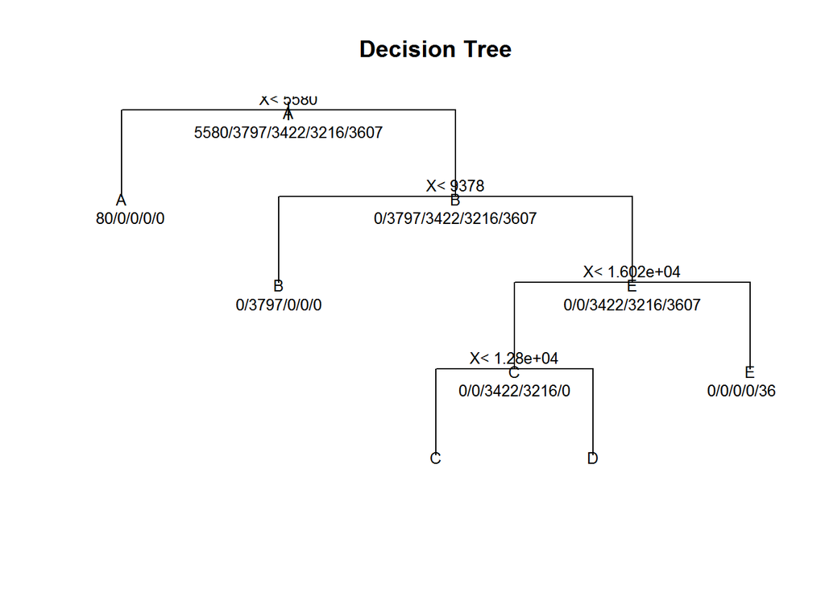

```r
## Print Tree
plot(model_tree, uniform=TRUE,
    main="Decision Tree")
    text(model_tree, use.n=TRUE, all=TRUE, cex=.8)
```

```r
    ## View Summary
summary(model_tree)
```

```
## Call:
## rpart(formula = classe ~ ., data = traindf, method = "class")
##   n= 19622
##
##          CP nsplit rel error       xerror         xstd
## 1 0.2704031      0 1.0000000 1.0000000000 0.0045001913
## 2 0.2568722      1 0.7295969 0.7296681384 0.0049829367
## 3 0.2436975      2 0.4727247 0.4728671129 0.0047201330
## 4 0.2290272      3 0.2290272 0.2291696340 0.0036937483
## 5 0.0100000      4 0.0000000 0.0002136448 0.0001233384
##
## Variable importance
##                    X       cvtd_timestamp            roll_belt
##                   41                   20                    4
##        pitch_forearm       pitch_dumbbell raw_timestamp_part_1
##                    4                    4                    4
##        roll_dumbbell    magnet_dumbbell_y         accel_belt_z
##                    3                    3                    3
##     accel_dumbbell_x        magnet_belt_y        magnet_belt_z
##                    3                    3                    3
##              yaw_arm          accel_arm_x           pitch_belt
##                    2                    2                    1
##    magnet_dumbbell_z
##                    1
##
## Node number 1: 19622 observations,    complexity param=0.2704031
##   predicted class=A  expected loss=0.7156253  P(node) =1
##     class counts:  5580  3797  3422  3216  3607
##    probabilities: 0.284 0.194 0.174 0.164 0.184
##   left son=2 (5580 obs) right son=3 (14042 obs)
##   Primary splits:
##       X              < 5580.5     to the left,  improve=4995.2530, (0 missing)
##       cvtd_timestamp splits as  LLLRLLRRLLRLLRLLRLLR, improve=2977.5510, (0 missing)
##       roll_belt      < 130.5      to the left,  improve=1477.9800, (0 missing)
##       pitch_forearm  < -33.95     to the left,  improve=1079.6910, (0 missing)
##       accel_belt_z   < -187.5     to the right, improve= 903.7195, (0 missing)
##   Surrogate splits:
##       cvtd_timestamp       splits as  LLRRLRRRLRRLRRLRRLRR, agree=0.880, adj=0.578, (0 split)
##       pitch_forearm        < -26.65     to the left,  agree=0.797, adj=0.284, (0 split)
##       raw_timestamp_part_1 < 1322490000 to the left,  agree=0.759, adj=0.153, (0 split)
```

[output cut: 66 more lines]

```
##
## Node number 15: 3607 observations
##   predicted class=E  expected loss=0  P(node) =0.1838243
##     class counts:     0     0     0     0  3607
##    probabilities: 0.000 0.000 0.000 0.000 1.000
##
## Node number 28: 3422 observations
##   predicted class=C  expected loss=0  P(node) =0.1743961
##     class counts:     0     0  3422     0     0
##    probabilities: 0.000 0.000 1.000 0.000 0.000
##
## Node number 29: 3216 observations
##   predicted class=D  expected loss=0  P(node) =0.1638977
##     class counts:     0     0     0  3216     0
##    probabilities: 0.000 0.000 0.000 1.000 0.000
```

```r
## View RSquared

rsq.rpart(model_tree)
```

```
##
## Classification tree:
## rpart(formula = classe ~ ., data = traindf, method = "class")
##
## Variables actually used in tree construction:
## [1] X
##
## Root node error: 14042/19622 = 0.71563
##
## n= 19622
##
##        CP nsplit rel error     xerror       xstd
## 1 0.27040      0   1.00000 1.00000000 0.00450019
## 2 0.25687      1   0.72960 0.72966814 0.00498294
## 3 0.24370      2   0.47272 0.47286711 0.00472013
## 4 0.22903      3   0.22903 0.22916963 0.00369375
## 5 0.01000      4   0.00000 0.00021364 0.00012334
```

[figure not shown]

[figure not shown]

I’m not really happy with the outcome of the decision tree, so I’m hoping that the outcome of the Random Forest is better.